# IE582_HW2

Yasemin Gokdag

October 25, 2018

## Data Cleaning and Setup

Similar to previous task, odds and match data and required libraries are loaded. The codes are not provided since it is exactly the same as the previous setup part

Data uploaded is examined to see if there is any duplicate records exist, match data has duplicate values, odds data doesn’t have any. These duplicate values are removed, and match and odds data are merged. After each step, columns that will not be needed are removed from data table to avoid complexity

```r
#Check for uniqueness of the data.
matchdata <- matchdata[, idCount := 1:.N, list(matchId)]
match_duplicates <- nrow(matchdata[idCount > 1])
```

```
## [1] "39 rows are duplciate"
```

data is not unique, remove duplicates and check for uniqueness in odd data

```r
#remove columns that are not necessary, get unique entries
matchdata <- matchdata[,-c( "idCount"), with=F]
matchdata <- unique(matchdata)
#Repeat for odds
odds <- odds[, rank := 1:.N, list(matchId,betType,oddtype,bookmaker,date,totalhandicap)]
odds[rank > 1]
#empty data table. There is no duplicate records, so data on odss data table is unique,
#we can join two data tables now.

odds <- odds[,-c( "rank"), with=F] #remove columns that are not necessary
#merge data, inner join
oddsandmatch <- merge(odds,matchdata, by.x= 'matchId' , by.y = 'matchId' , all.x = FALSE, all.y =  FALSE )
#make sure that resulting table is a data table
oddsandmatch <- as.data.table(oddsandmatch)

#we get rid of leagueId  and type since there is no information
oddsandmatch <- oddsandmatch[,-c("leagueId","type"), with=F]
setnames(oddsandmatch, 'date.x', 'oddDate')
setnames(oddsandmatch, 'date.y', 'matchDate')
```

After obtaining merged data, we perform date transformations, remove matches that are not played yet and obtain final bets

```r
#Transform date
oddsandmatch[,oddDateTime := anytime(oddDate)]
#Since we will work on both odds and match outcomes, we should only consider actualized games.
oddsandmatch <- oddsandmatch[!is.na(score)]
#get final bets
finalbets <- oddsandmatch[order(-oddDateTime), rank := 1:.N, list(bookmaker, betType, oddtype, matchId, totalhandicap)]
finalbets <- finalbets[rank == 1 ]
```

Bookmakers are selected based on distinct count of matches that they offer odds, and other bookmakers’ data is removed. Detailed codes can be found on *Appendix*

Below are the selected bookmakers

```
##    BookmakersSelected
## 1:              10Bet
## 2:              12BET
## 3:             188BET
## 4:        bet-at-home
## 5:             bet365
## 6:            Betclic
## 7:            Betsafe
## 8:            Betsson
```

Odds are transformed into probabilites so that all of them would be in 0-1 interval.

Then, over labels are assigned based on actual match scores with total handicap 2.5. Label EndResult is a binary variable that takes value 1 if total score > 2.5, and 0 otherwise.

Home-Tie-Away labels are assigned, HTAResults takes value 1 if home wins, 2 if away wins and 0 if tie.

Detailed codes can be found in *Appendix*

Also, I removed all information related to “Asian Handicap” bets, because the variety caused by its handicaps is too much and honestly I could not understand how it works, so I won’t be able to comment on it.

# Task 1 a,b,c & Task 2

We have cleaned data now, for this task each bookmaker will be examined seperately.

For PCA we need to get unique identifiers based on betType, oddtype and totalhandicap. The data that we will perform PCA on will have matchId’s in rows, and above mentioned identifiers as feature vectors in columns. And this data set will be prepared for each bookmaker.

But we have a problem here. There are too many betTypes, and for some betTypes like *ou* totalhandicap values create even more variety. Because of that, for each match, data table crated based on description above has many NA values on columns. PCA does not work while we have missing entires, and using only complete cases reduces the number of rows too much, that they become less than number of columns.

To address this issue, I created a two phased solution, I will describe in detail below.

To begin with, class values are created as follows,

```r
#Combine class values
finalbets_filtered <- finalbets_filtered[ !is.na(totalhandicap) , Class := paste0( betType, "|" , oddtype , "|" ,totalhandicap, sep = "") ]
finalbets_filtered <- finalbets_filtered[ is.na(totalhandicap) , Class := paste0( betType, "|" , oddtype , sep = "") ]
```

Then, as phase 1, number of non-NA rows are found per bookmaker per class, and per class. Detailed code can be found in *Appendix*, below is the summary of this data

```
##    Min. 1st Qu.  Median    Mean 3rd Qu.    Max.
##       1      67    1661    1475    2809    3074
```

```
##    Min. 1st Qu.  Median    Mean 3rd Qu.    Max.
##       1       2      89    4838    9229   24592
```

Removal code can be found in *Appendix*

```
##    Min. 1st Qu.  Median    Mean 3rd Qu.    Max.
##     563    2127    2818    2539    2882    3074
```

```
##    Min. 1st Qu.  Median    Mean 3rd Qu.    Max.
##    3079   10210   15623   15699   21927   24592
```

New summary shows closer median and mean values, so our work here is done.

As phase2, I will replace NA values based on a criteria. To determine the Class values that have NA values per bookmaker, I pivot data, and unpivot pivotted data. In this way, NA values are printed automatically for missing values. Details of this code can be found in *Appendix*

Then, I filled NA values with median of the odd probabilites of bookmakers per matchId per Class. This is based on the assumption that bookmakers will act similar on the same matches in terms of probability of each oddType. Of course, if a Class value , say “1x2|odd1” , is never played on that match, we would not be able to fill NA’s

```r
data_melted[,value := ifelse(is.na(value), median(value, na.rm=TRUE), value), by= list(matchId,variable)]
```

From now on, we perform every step for each bookmaker. Code on *Appendix* provides standart form of what I have performed per bookmaker.

For each bookmaker, data is pivotted again so that Class variables are in columns, NA’s are omitted and data is standardized with scale function. Then primcomp is performed.

For 10Bet, the summary is as follows.

These results suggests that by choosing components 1 and 2 we are explaning 75% percent of the variance. And marginal increase in information gain decreases as number of components increase.

Results for other bookmakers are very similar.

Below the summary are the color coded graphs of new coordinates per each bookmaker. We cannot really see a distinction between over/under bets. However, as we can observe, home and away points are distinuished easily from the graph.

For each bookamaker, MDS is performed based on Eucledian and Manhattan Distances. MDS codes can be found in *Appendix*. The resulting graphs are similiar to what we have seen in PCA part. Density of the points changes, and the position of the points with “home wins” and “away wins” changes, but still, we cannot really see a distinction between over/under bets. Home and away points are distinuished easily from the graph.

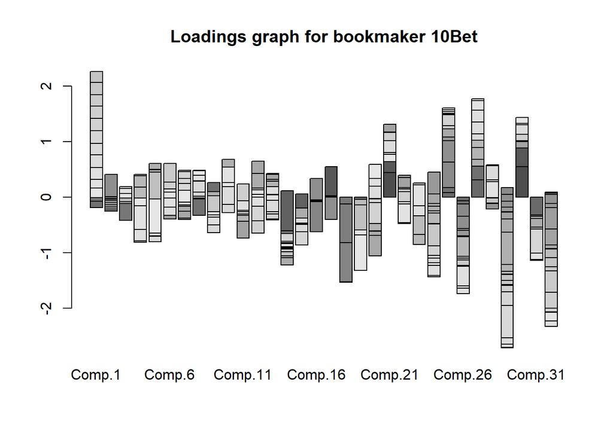

```
## Importance of components:
##                           Comp.1    Comp.2    Comp.3     Comp.4     Comp.5
## Standard deviation     4.2804714 2.4072508 1.7405860 1.24861430 1.00345231
## Proportion of Variance 0.5740442 0.1815536 0.0949190 0.04884485 0.03154682
## Cumulative Proportion  0.5740442 0.7555978 0.8505168 0.89936169 0.93090851
##                            Comp.6     Comp.7     Comp.8      Comp.9
## Standard deviation     0.75161521 0.66506302 0.51433447 0.470977796
## Proportion of Variance 0.01769919 0.01385759 0.00828807 0.006949652
## Cumulative Proportion  0.94860770 0.96246529 0.97075336 0.977703015
##                            Comp.10     Comp.11     Comp.12     Comp.13
## Standard deviation     0.437521477 0.358334755 0.349381190 0.309196549
## Proportion of Variance 0.005997371 0.004022907 0.003824382 0.002995239
## Cumulative Proportion  0.983700386 0.987723293 0.991547675 0.994542913
##                            Comp.14    Comp.15      Comp.16     Comp.17
## Standard deviation     0.285147306 0.27687673 0.1066819114 0.069488669
## Proportion of Variance 0.002547421 0.00240179 0.0003565691 0.000151283
## Cumulative Proportion  0.997090334 0.99949212 0.9998486938 0.999999977
##                             Comp.18      Comp.19      Comp.20      Comp.21
## Standard deviation     8.601430e-04 9.464235e-08 4.644249e-08 2.799053e-08
## Proportion of Variance 2.317947e-08 2.806294e-16 6.757612e-17 2.454622e-17
## Cumulative Proportion  1.000000e+00 1.000000e+00 1.000000e+00 1.000000e+00
##                             Comp.22      Comp.23      Comp.24      Comp.25
## Standard deviation     2.369974e-08 2.348176e-08 1.997796e-08 1.601862e-08
## Proportion of Variance 1.759743e-17 1.727521e-17 1.250445e-17 8.039196e-18
## Cumulative Proportion  1.000000e+00 1.000000e+00 1.000000e+00 1.000000e+00
##                             Comp.26      Comp.27 Comp.28 Comp.29 Comp.30
## Standard deviation     1.510467e-08 1.292614e-08       0       0       0
## Proportion of Variance 7.147998e-18 5.234801e-18       0       0       0
## Cumulative Proportion  1.000000e+00 1.000000e+00       1       1       1
##                        Comp.31 Comp.32
## Standard deviation           0       0
## Proportion of Variance       0       0
## Cumulative Proportion        1       1
##
## Loadings:
##               Comp.1 Comp.2 Comp.3 Comp.4 Comp.5 Comp.6 Comp.7 Comp.8
## 1x2|odd1              0.403
## 1x2|odd2             -0.405
## 1x2|oddX                    -0.497 -0.160 -0.109  0.109
## bts|NO        -0.113         0.480                             -0.293
```

[output cut: 145 more lines]

```
## ou|over|3.5    0.172          -0.262
## ou|over|4.5                    0.254
## ou|over|5.5           -0.135  -0.154
## ou|over|6.5    0.104
## ou|under|0.5                  -0.165
## ou|under|1.5           0.193
## ou|under|2    -0.241          -0.387
## ou|under|2.25  0.245   0.168  -0.289
## ou|under|2.5                  -0.181
## ou|under|2.75         -0.548
## ou|under|3                     0.190
## ou|under|3.5   0.172          -0.262
## ou|under|4.5                   0.254
## ou|under|5.5          -0.135  -0.154
## ou|under|6.5   0.104
```

Plots are as follows :

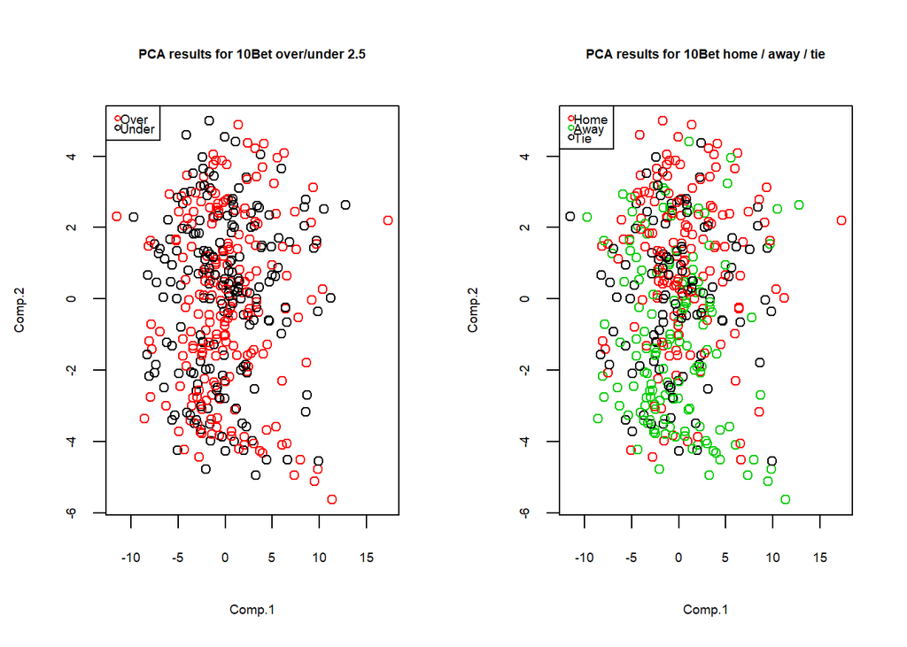

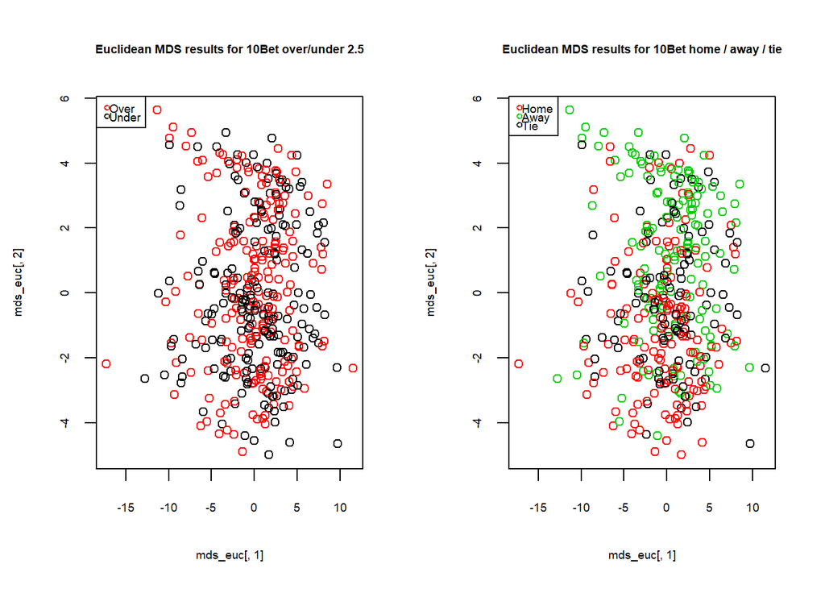

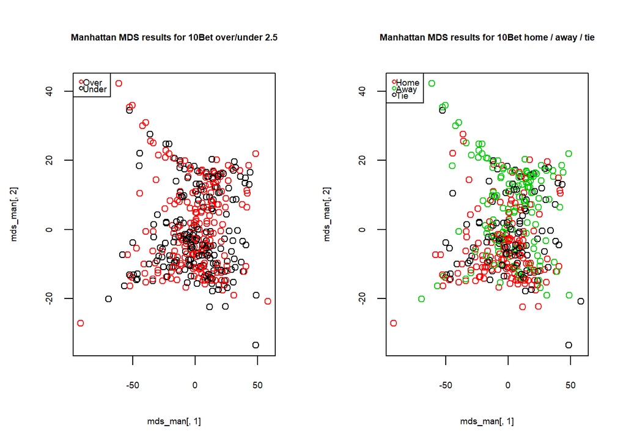

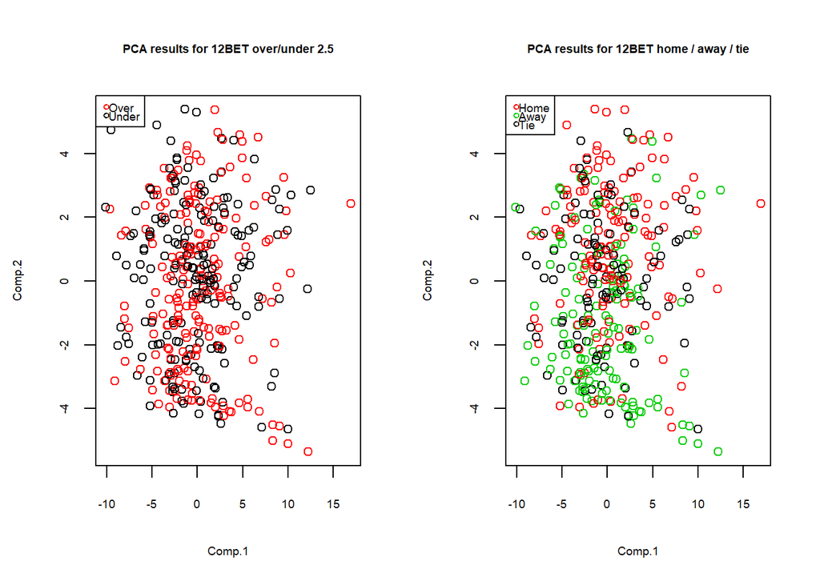

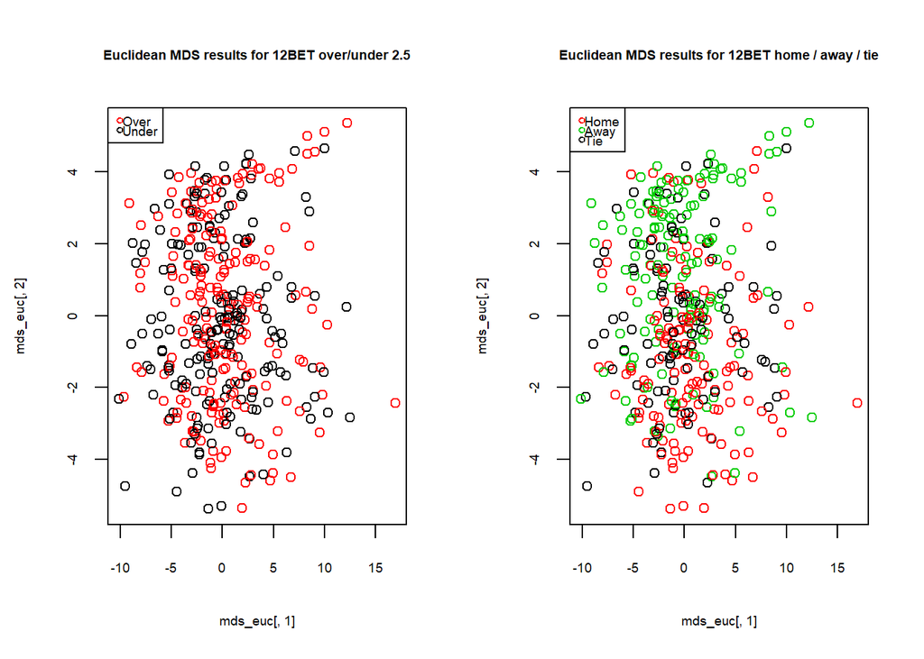

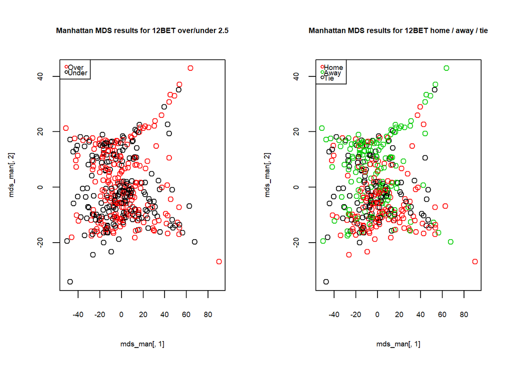

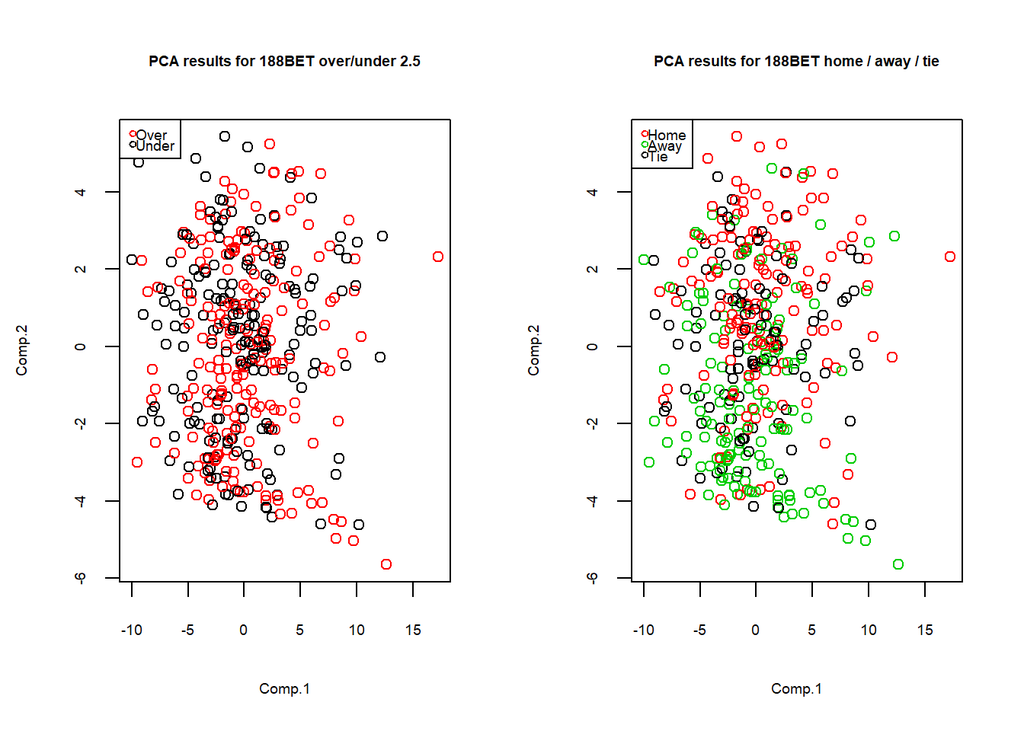

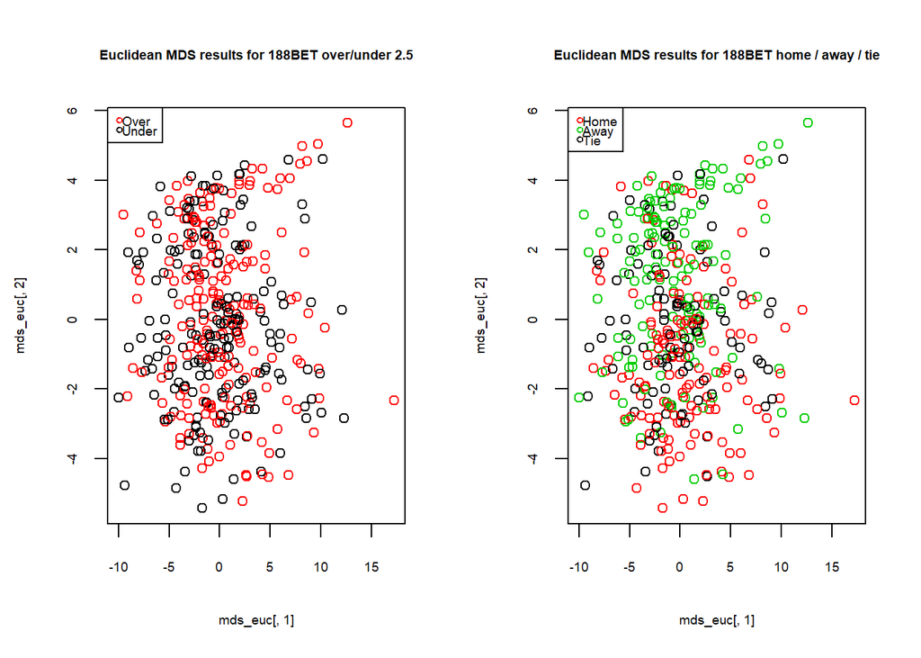

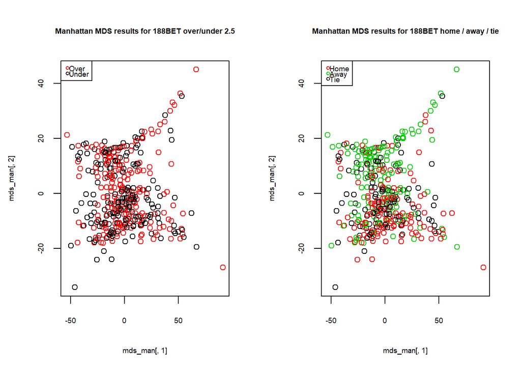

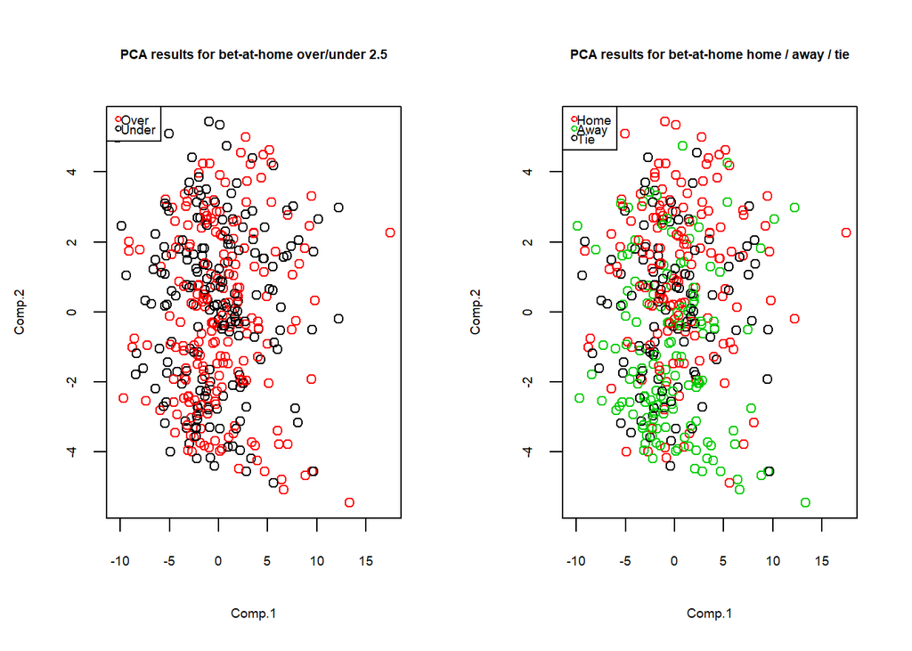

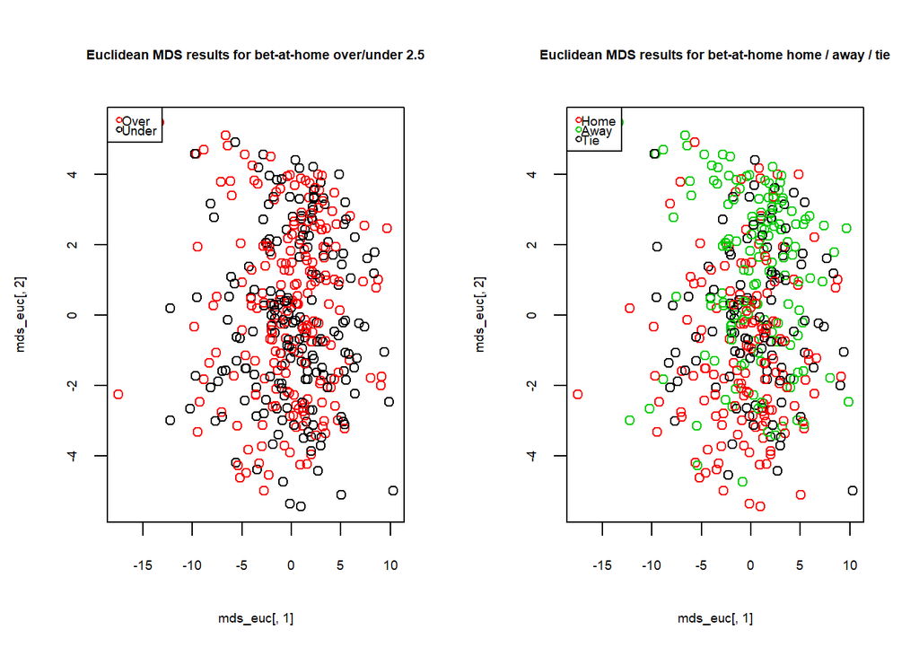

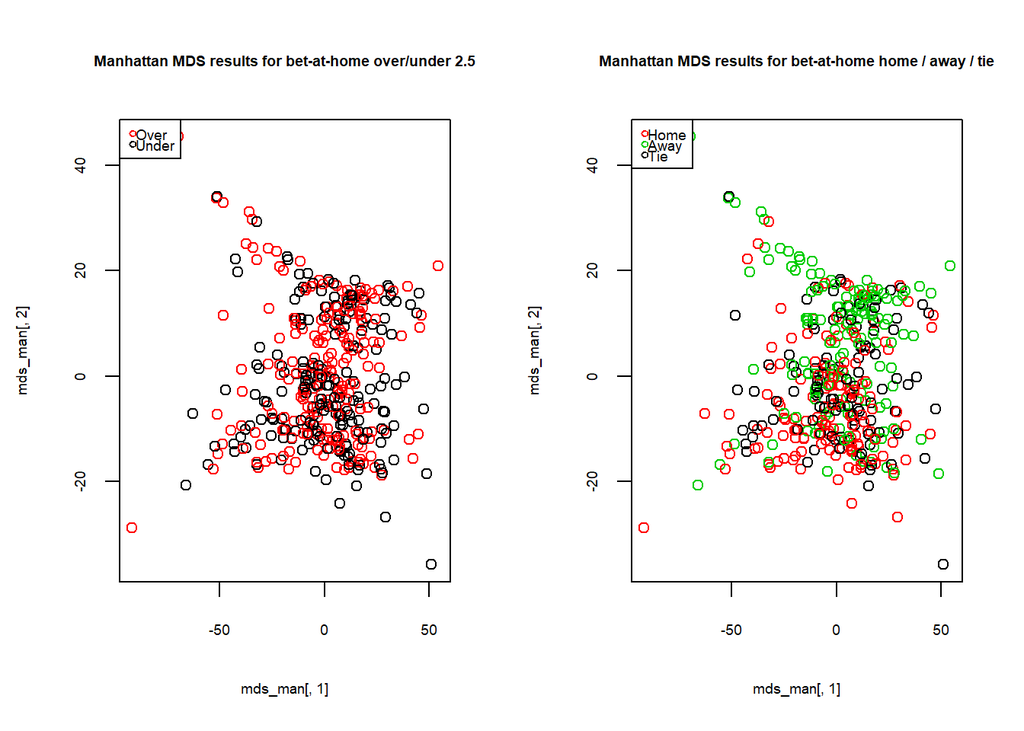

[12 more figures not shown]

# Task 3

Detailed codes can be found in *Appendix*

### 1

Picture is read as follows using jpeg package

```r
require(jpeg)
img <- readJPEG("C:/Users/yasemin/Desktop/small_img.jpg")
```

Resulting image is an array with 786432 elements

### 2

Printed image is :

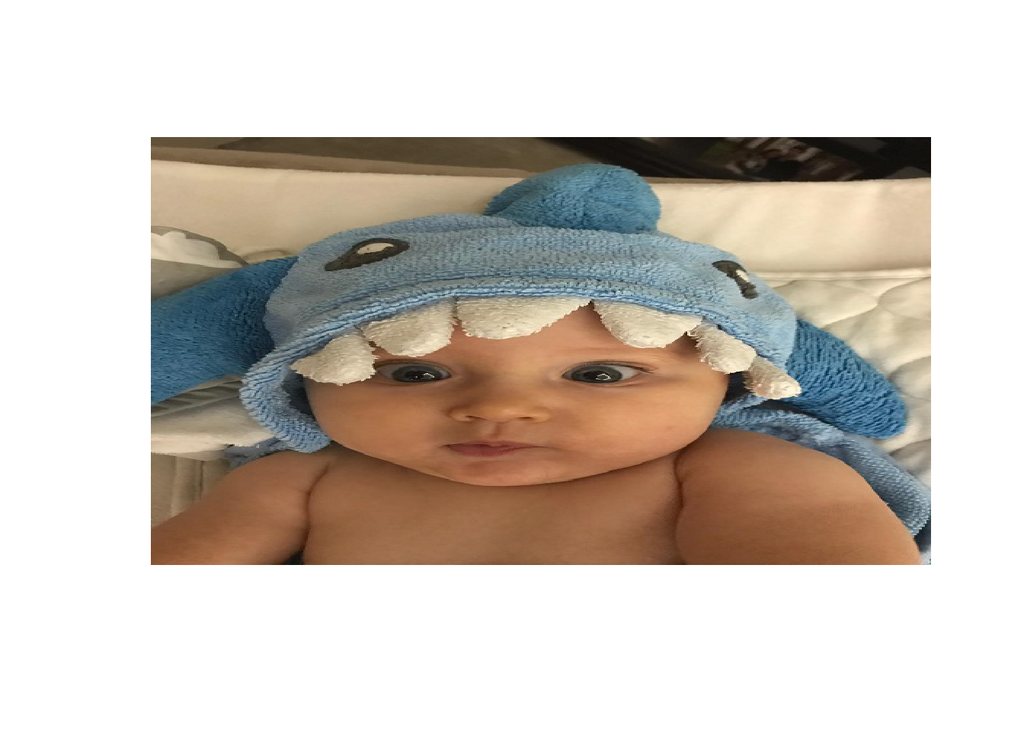

For this part I used par(mfrow=c(1,3)) function but somehow I could not manage to plot on the same row

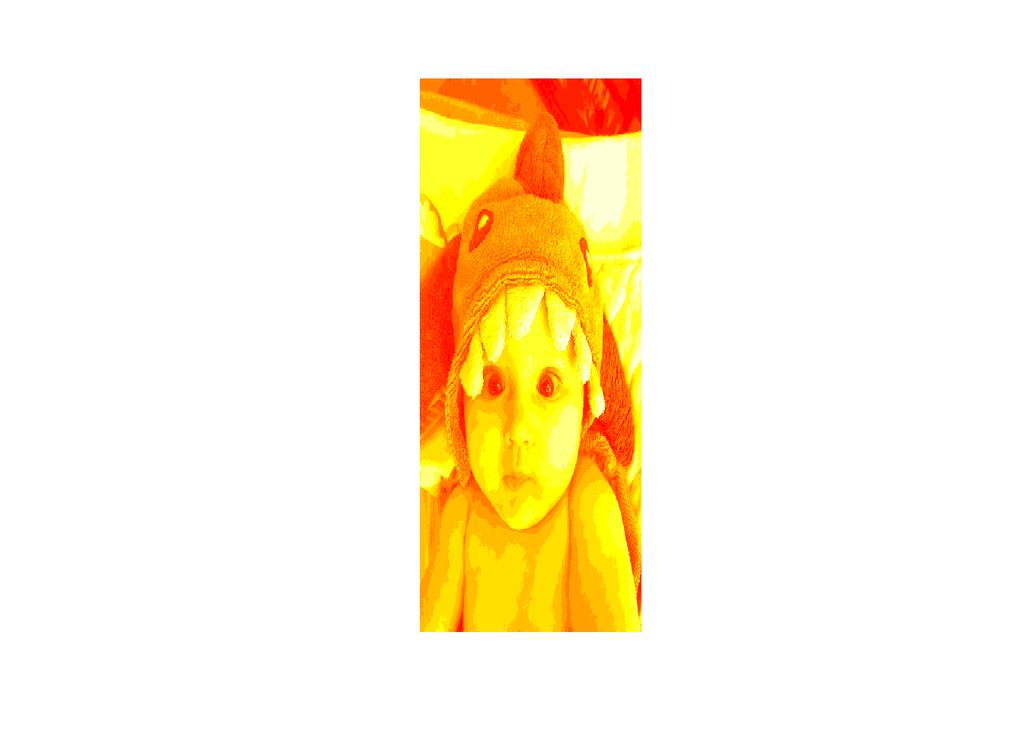

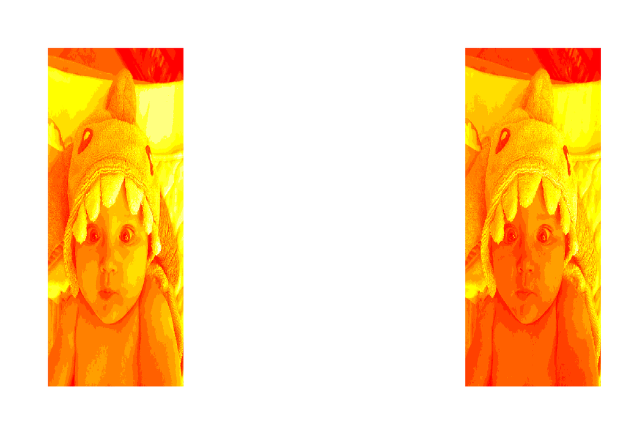

Probably because of similar density of red, green and blue , all graphs look orange-ish

### 3

Add noise on the image and display :

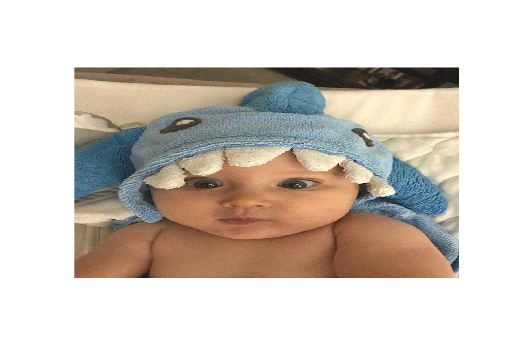

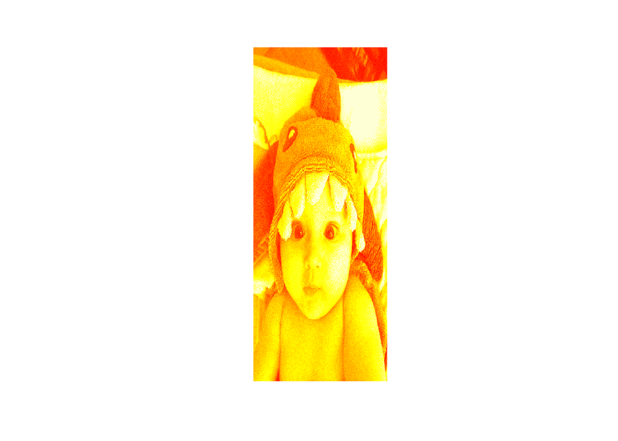

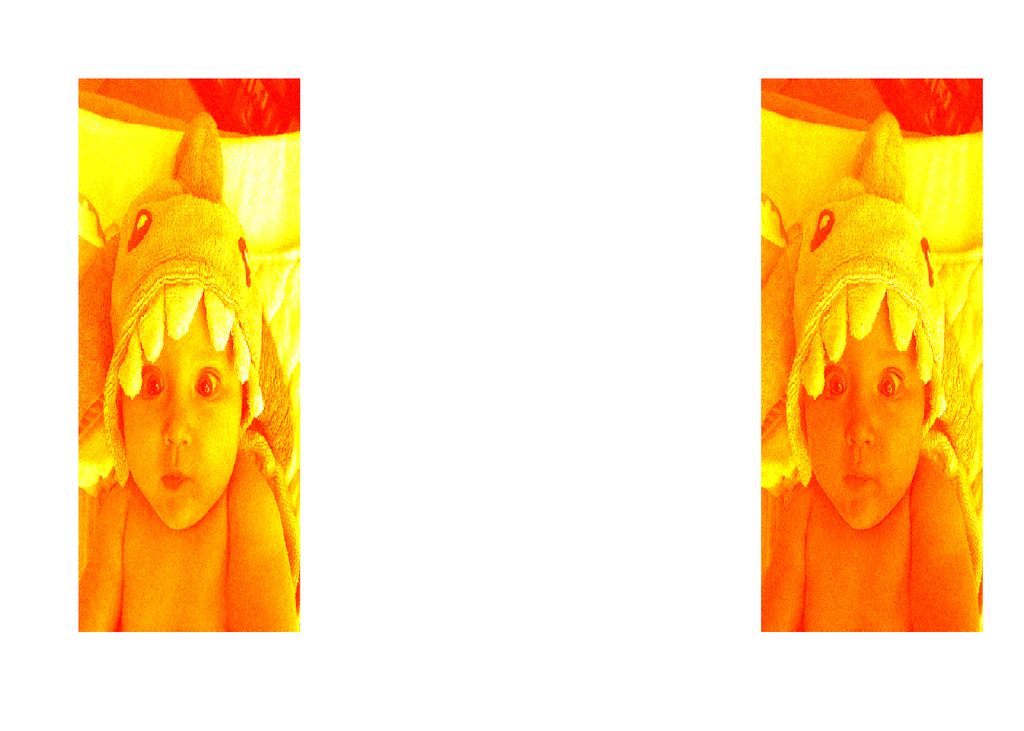

# Appendix

Bookmaker selection :

```r
#Now we  reduce the number of selected bookmakers to 8 based on count of distinct games that they offered odds
match_count <- finalbets[, list(Count = length(unique(matchId))), by = c("bookmaker")]
BookmakersSelected <- match_count[order(-Count), head(.SD,8)]$bookmaker
BookmakersSelected <- as.data.table(BookmakersSelected)

finalbets_filtered <- merge(finalbets, BookmakersSelected , by.x = 'bookmaker', by.y = 'BookmakersSelected', all.x = FALSE, all.y = FALSE)
finalbets_filtered <- as.data.table(finalbets_filtered)
```

Converting odds to probabilities :

```r
finalbets_filtered[, p1 := 1/odd ]
finalbets_filtered[ , probsum := sum(p1), by = list(bookmaker, matchId, betType, totalhandicap)]
finalbets_filtered[, probability := p1/probsum ]
```

Labelling actual results as over based on total handicap 2.5 :

```r
#mark actual overs by 2.5 total handicap
finalbets_filtered <- finalbets_filtered[, c("home_score", "away_score") := tstrsplit(score, ":", fixed=TRUE)]
finalbets_filtered$home_score <- as.numeric(finalbets_filtered$home_score)
finalbets_filtered$away_score <- as.numeric(finalbets_filtered$away_score)

#if over 1, else 0
finalbets_filtered[home_score+away_score > 2.5, EndResult := 1 ]
finalbets_filtered[is.na(EndResult), EndResult := 0 ]
finalbets_filtered <- finalbets_filtered[,-c("p1","probsum"), with=F]

#Home-Tie-Away Results, if home 1 if away 2 if tie 0
finalbets_filtered[home_score > away_score , HTAResult := 1 ]
finalbets_filtered[home_score < away_score , HTAResult := 2 ]
finalbets_filtered[is.na(HTAResult), HTAResult := 0 ]

finalbets_filtered <- finalbets_filtered[betType != "ah"]
```

Calculating number of non_NA columns per bookmaker & Class :

```r
#At this point we calculate how many rows of data we actually have for each  "class",
#There can be "class"es that occurs on one row only, such small data sample affect our analysis
#since they would be outliers
data_points_bm_cl <- finalbets_filtered[, list(Count = length(matchId)), by = c("bookmaker","Class")]
data_points_cl <- finalbets_filtered[, list(Count = length(matchId)), by = c("Class")]
```

```r
finalbets_filtered2 <- merge(finalbets_filtered, data_points_bm_cl, by.x = c("bookmaker", "Class"), by.y= c("bookmaker" ,"Class")
              , all.x = TRUE, all.y = TRUE)

finalbets_filtered2 <- merge(finalbets_filtered2, data_points_cl, by.x = "Class", by.y = "Class", all.x = TRUE, all.y= TRUE)
     finalbets_filtered2 <- finalbets_filtered2[Count.x > 500]
finalbets_filtered2 <- finalbets_filtered2[Count.y > 2500]
```

Pivot & melt to replace NAs :

```r
#pivot and melt to determine missing values
data <- cbind(finalbets_filtered2$matchId , finalbets_filtered2$EndResult, finalbets_filtered2$HTAResult, finalbets_filtered2$probability, finalbets_filtered2$bookmaker, finalbets_filtered2$Class)
data <- as.data.table(data)
setnames(data,c("matchId", "EndResult","HTAResult","probability", "bookmaker", "Class"))
data_pivot <- dcast(data, matchId + EndResult + HTAResult + bookmaker ~ Class, value.var =  "probability")
data_melted <- melt(data_pivot, id.vars=c("matchId","EndResult","HTAResult","bookmaker")
                                           , measure.vars = c("1x2|odd1",   "1x2|odd2", "1x2|oddX", "bts|NO",   "bts|YES",  "dc|12",    "dc|1X",    "dc|X2",    "ha|1", "ha|2", "ou|over|0.5",  "ou|over|1.5",  "ou|over|2",    "ou|over|2.25", "ou|over|2.5",  "ou|over|2.75", "ou|over|3",    "ou|over|3.5",  "ou|over|4.5",  "ou|over|5.5",  "ou|over|6.5",  "ou|under|0.5", "ou|under|1.5", "ou|under|2",   "ou|under|2.25",    "ou|under|2.5", "ou|under|2.75",    "ou|under|3",   "ou|under|3.5", "ou|under|4.5", "ou|under|5.5", "ou|under|6.5"))

data_melted$value <- as.numeric(data_melted$value)
```

PCA per bookmaker standard code :

```r
#i in 1:nrow(BookmakersSelected)
i = 1

data_bm <- data_melted[bookmaker == BookmakersSelected[i]]
data_bm$value <- as.numeric(data_bm$value)
data_bm_pivot <- dcast(data_bm, matchId + EndResult + HTAResult ~ variable, value.var = "value")
data_bm_pivot <- na.omit(data_bm_pivot)

col <- ncol(data_bm_pivot)
row <- nrow(data_bm_pivot)

scaled_data <- matrix(data=NA, nrow = row, ncol = col)
scaled_data <- as.data.table(scaled_data)
data_bm_pivot<- as.data.table(data_bm_pivot)
scaled_data[,1:3] <- data_bm_pivot[,1:3]

colnames <- names(data_bm_pivot)

for (j in 4:col)
{
  scaled_data[,j] <- scale(data_bm_pivot[,get(colnames[j])])
  j = j+1
}

setnames(scaled_data, colnames)

pca_prin <- princomp(scaled_data[,4:ncol(scaled_data)])

color_over <- scaled_data$EndResult
color_over <- as.numeric(color_over)

color_hta <- scaled_data$HTAResult
color_hta <- as.numeric(color_hta)

legend_over <- cbind(c("Over", "Under"),c(2,1))
legend_over[,2] <- as.numeric(legend_over[,2])
legend_over <- as.data.table(legend_over)
setnames(legend_over,c("Label","Color"))

legend_HTA <- cbind(c("Home", "Away", "Tie"), c(2,3,1))
legend_HTA[,2] <- as.numeric(legend_HTA[,2])
legend_HTA <- as.data.table(legend_HTA)
setnames(legend_HTA,c("Label","Color"))


par(mfrow=c(1,2))

plot(pca_prin$scores, main = paste0("PCA results for " , BookmakersSelected[i] , " over/under 2.5"), col = color_over + 1 )
legend("topleft",unique(legend_over$Label) ,col=unique(legend_over$Color) , pch = 1, bty = "o"
       , xjust =1 , yjust=1, x.intersp = 0.2,y.intersp = 0.3)

plot(pca_prin$scores, main = paste0("PCA results for " , BookmakersSelected[i] , " home / away / tie"), col = color_hta + 1 )
legend("topleft",unique(legend_HTA$Label) ,col=unique(legend_HTA$Color) , pch = 1, bty = "o"
       , xjust =1 , yjust=1, x.intersp = 0.2,y.intersp = 0.3)
```

MDS standard code per bookmaker :

```r
#MDS

#Calculate distance matrices

col <- ncol(scaled_data)
euclideanMDS=dist(scaled_data[,4:col],diag= T, upper = T )
manhattanMDS=dist(scaled_data[,4:col],method = "manhattan")

mds_euc <- cmdscale(euclideanMDS)

par(mfrow=c(1,2))

plot(mds_euc[,1], mds_euc[,2],main = paste0("Euclidean MDS results for " , BookmakersSelected[i] , " over/under 2.5"),  col = color_over+1 )
legend("topleft",unique(legend_over$Label) ,col=unique(legend_over$Color) , pch = 1, bty = "o"
       , xjust =1 , yjust=1, x.intersp = 0.2,y.intersp = 0.6)

plot(mds_euc[,1], main = paste0("Euclidean MDS results for " , BookmakersSelected[i] , " home / away / tie"), mds_euc[,2], col = color_hta+1 )
legend("topleft",unique(legend_HTA$Label) ,col=unique(legend_HTA$Color) , pch = 1, bty = "o"
       , xjust =1 , yjust=1, x.intersp = 0.2,y.intersp = 0.6)


mds_man <- cmdscale(manhattanMDS)

par(mfrow=c(1,2))

plot(mds_man[,1], mds_man[,2],main = paste0("Manhattan MDS results for " , BookmakersSelected[i] , " over/under 2.5"),  col = color_over+1 )
legend("topleft",unique(legend_over$Label) ,col=unique(legend_over$Color) , pch = 1, bty = "o"
       , xjust =1 , yjust=1, x.intersp = 0.2,y.intersp = 0.6)

plot(mds_man[,1], mds_man[,2], main = paste0("Manhattan MDS results for " , BookmakersSelected[i] , " home / away / tie"), col = color_hta+1 )
legend("topleft",unique(legend_HTA$Label) ,col=unique(legend_HTA$Color) , pch = 1, bty = "o"
       , xjust =1 , yjust=1, x.intersp = 0.2,y.intersp = 0.6)
```

Draw image :

```r
par(mfrow=c(1,1))
plot(0:1,0:1,type= "n" ,ann = FALSE, axes = FALSE)
rasterImage(img,0,0,1,1, interpolate = FALSE)
```

Draw image components :

```r
#Take reverse of each [img,,i] i in (1:3) since image is upside down otherwise.
par(mfrow=c(1,3))

plot(0:1,0:1,type= "n" , ann = FALSE, axes = FALSE)
image(t(apply(img[,,1], 2, rev)), axes= FALSE )

plot(0:1,0:1,type= "n" , ann = FALSE, axes = FALSE)
image(t(apply(img[,,2], 2, rev)), axes = FALSE)

plot(0:1,0:1,type= "n" , ann = FALSE, axes = FALSE)
image(t(apply(img[,,3], 2, rev)), axes = FALSE)
```

Create random noise on image :

```r
noised <- array(data=NA, dim = c(512,512,3))

noised[,,1]<-img[,,1] + matrix(runif(512*512,0,0.1),512,512)
noised[,,2]<-img[,,2] + matrix(runif(512*512,0,0.1),512,512)
noised[,,3]<-img[,,3] + matrix(runif(512*512,0,0.1),512,512)

noised[,,1][noised[,,1]>1] <- rep(1, length(noised[,,1][noised[,,1]>1]))
noised[,,2][noised[,,2]>1] <- rep(1, length(noised[,,2][noised[,,2]>1]))
noised[,,3][noised[,,3]>1] <- rep(1, length(noised[,,3][noised[,,3]>1]))
```